## *Hsin-Chieh Tang* **s4647300**

# Assignment 2

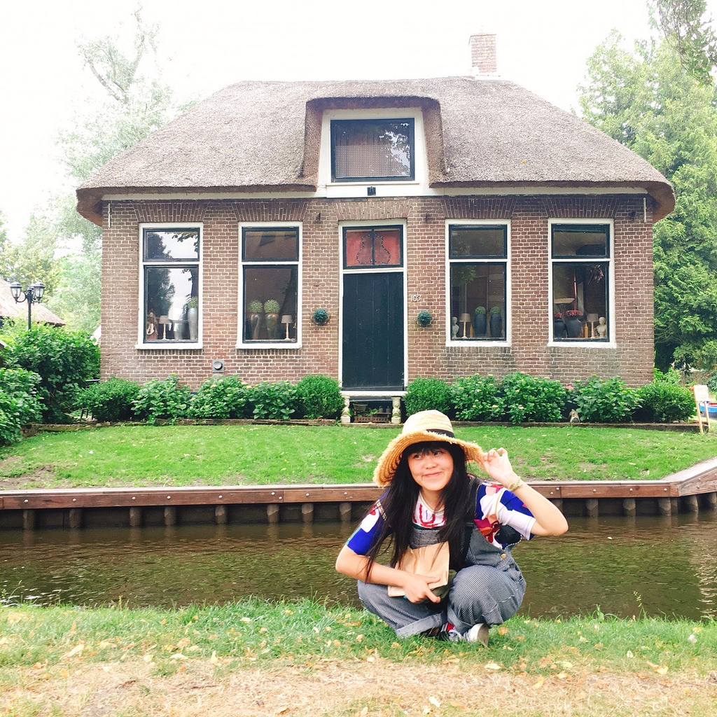

### Dataset

#### This dataset is regarding a survey from 1,058 American respondents responses about what they eat on Thanksgiving in 2015. I have imported the dataset by using `read_csv()` and named this dataset to *thanksmeals*.

```r
thanksmeals <- read_csv("thanksgiving_meals.csv")
```

### Part 2: Data Wrangling and Visualization (60 Marks)

For all tables below, you need to use the RMarkdown functionality to present tables (`kable`).

### 1. Display the first 10 rows of the dataset using RMarkdown

#### By using `head()`function can display 6 rows of the dataset automatically, I put 10 based on the requirements and used `kable()` to show the results in the table.

```r
head(thanksmeals, 10) %>% kable()
```

| id | celebrate | main_dish | main_dish_other | main_prep | main_prep_other | stuffing | stuffing_other | cranberry | cranberry_other | gravy | side1 | side2 | side3 | side4 | side5 | side6 | side7 | side8 | side9 | side10 | side11 | side12 | side13 | side14 | side15 | pie1 | pie2 | pie3 | pie4 | … |
| --- | --- | --- | --- | --- | --- | --- | --- | --- | --- | --- | --- | --- | --- | --- | --- | --- | --- | --- | --- | --- | --- | --- | --- | --- | --- | --- | --- | --- | --- | --- |
| 4337954960 | Yes | Turkey | NA | Baked | NA | Bread-based | NA | None | NA | Yes | NA | Carrots | NA | NA | NA | NA | Green beans/green bean casserole | Macaroni and cheese | Mashed potatoes | NA | NA | NA | Yams/sweet potato casserole | NA | NA | Apple | NA | NA | NA | … |
| 4337951949 | Yes | Turkey | NA | Baked | NA | Bread-based | NA | Other (please specify) | Homemade cranberry gelatin ring | Yes | NA | NA | NA | Corn | NA | NA | Green beans/green bean casserole | Macaroni and cheese | Mashed potatoes | Rolls/biscuits | NA | Vegetable salad | Yams/sweet potato casserole | Other (please specify) | Asian vinagrette salad | Apple | NA | NA | Chocolate | … |
| 4337935621 | Yes | Turkey | NA | Roasted | NA | Rice-based | NA | Homemade | NA | Yes | Brussel sprouts | Carrots | Cauliflower | Corn | Cornbread | NA | NA | NA | Mashed potatoes | Rolls/biscuits | NA | Vegetable salad | NA | NA | NA | Apple | NA | Cherry | NA | … |
| 4337933040 | Yes | Turkey | NA | Baked | NA | Bread-based | NA | Homemade | NA | Yes | Brussel sprouts | NA | NA | NA | Cornbread | NA | NA | NA | Mashed potatoes | Rolls/biscuits | NA | Vegetable salad | Yams/sweet potato casserole | NA | NA | NA | NA | NA | NA | … |
| 4337931983 | Yes | Tofurkey | NA | Baked | NA | Bread-based | NA | Canned | NA | Yes | Brussel sprouts | NA | NA | NA | Cornbread | NA | NA | NA | Mashed potatoes | Rolls/biscuits | Squash | Vegetable salad | Yams/sweet potato casserole | NA | NA | Apple | NA | NA | NA | … |
| 4337929779 | Yes | Turkey | NA | Roasted | NA | Rice-based | NA | Homemade | NA | Yes | Brussel sprouts | Carrots | Cauliflower | Corn | Cornbread | Fruit salad | Green beans/green bean casserole | Macaroni and cheese | Mashed potatoes | Rolls/biscuits | Squash | Vegetable salad | Yams/sweet potato casserole | NA | NA | NA | NA | NA | NA | … |
| 4337924420 | Yes | Turkey | NA | Baked | NA | Bread-based | NA | Canned | NA | Yes | NA | NA | NA | NA | NA | Fruit salad | Green beans/green bean casserole | NA | Mashed potatoes | Rolls/biscuits | NA | NA | Yams/sweet potato casserole | NA | NA | Apple | NA | NA | NA | … |
| 4337916002 | Yes | Turkey | NA | Baked | NA | Rice-based | NA | Homemade | NA | Yes | NA | Carrots | NA | NA | NA | NA | NA | NA | NA | NA | NA | NA | NA | NA | NA | NA | NA | NA | Chocolate | … |
| 4337914977 | Yes | Turkey | NA | Roasted | NA | Bread-based | NA | Canned | NA | Yes | Brussel sprouts | NA | NA | Corn | Cornbread | NA | Green beans/green bean casserole | NA | Mashed potatoes | Rolls/biscuits | Squash | NA | NA | NA | NA | Apple | Buttermilk | NA | NA | … |
| 4337899817 | Yes | Other (please specify) | Turkey and Ham | Baked | NA | Bread-based | NA | Other (please specify) | Both Canned and Homemade | Yes | Brussel sprouts | Carrots | NA | NA | NA | NA | Green beans/green bean casserole | NA | Mashed potatoes | Rolls/biscuits | NA | NA | Yams/sweet potato casserole | NA | NA | NA | Buttermilk | NA | NA | … |

### 2. Use `fct_reorder` and `parse_number` functions to create a factor variable `family_income`

#### This question requires us to transform the categorical (character) variables ‘family_income’ into factor variable. By using `class()` to check it is character,the next step is to use `parse_number(var_name)`function, which can remove any non-numeric characters before or after the first number. The syntax is **data %>% mutate(var_name = fct_reorder(var_name, parse_number(var_name)))**. Besides, I saved as a new dataset ‘family_income’. Finally, we can use `class()` again to have a simple view and it convert to factor; we also can use `skim()`to ckeck as well.

```r
# To check the class of family income

class(thanksmeals$family_income)
```

```
## [1] "character"
```

```r
# To transform 'family_income' into factor variable

family_income <- thanksmeals %>%
  mutate(family_income = fct_reorder(family_income, parse_number(family_income)))
# To ckeck if it is a factor

class(family_income$family_income)
```

```
## [1] "factor"
```

```r
skim(family_income)
```

Data summary

| Name | family_income |
| --- | --- |
| Number of rows | 1058 |
| Number of columns | 65 |
| _______________________ |  |
| Column type frequency: |  |
| character | 63 |
| factor | 1 |
| numeric | 1 |
| ________________________ |  |
| Group variables | None |

**Variable type: character**

| skim_variable | n_missing | complete_rate | min | max | empty | n_unique | whitespace |
| --- | --- | --- | --- | --- | --- | --- | --- |
| celebrate | 0 | 1.00 | 2 | 3 | 0 | 2 | 0 |
| main_dish | 84 | 0.92 | 6 | 22 | 0 | 8 | 0 |
| main_dish_other | 1023 | 0.03 | 4 | 85 | 0 | 32 | 0 |
| main_prep | 84 | 0.92 | 5 | 22 | 0 | 5 | 0 |
| main_prep_other | 1007 | 0.05 | 1 | 33 | 0 | 32 | 0 |
| stuffing | 84 | 0.92 | 4 | 22 | 0 | 4 | 0 |
| stuffing_other | 1022 | 0.03 | 4 | 46 | 0 | 29 | 0 |
| cranberry | 84 | 0.92 | 4 | 22 | 0 | 4 | 0 |
| cranberry_other | 1033 | 0.02 | 3 | 61 | 0 | 24 | 0 |
| gravy | 84 | 0.92 | 2 | 3 | 0 | 2 | 0 |
| side1 | 903 | 0.15 | 15 | 15 | 0 | 1 | 0 |
| side2 | 816 | 0.23 | 7 | 7 | 0 | 1 | 0 |
| side3 | 970 | 0.08 | 11 | 11 | 0 | 1 | 0 |
| side4 | 594 | 0.44 | 4 | 4 | 0 | 1 | 0 |
| side5 | 823 | 0.22 | 9 | 9 | 0 | 1 | 0 |
| side6 | 843 | 0.20 | 11 | 11 | 0 | 1 | 0 |
| side7 | 372 | 0.65 | 32 | 32 | 0 | 1 | 0 |
| side8 | 852 | 0.19 | 19 | 19 | 0 | 1 | 0 |
| side9 | 241 | 0.77 | 15 | 15 | 0 | 1 | 0 |
| side10 | 292 | 0.72 | 14 | 14 | 0 | 1 | 0 |
| side11 | 887 | 0.16 | 6 | 6 | 0 | 1 | 0 |
| side12 | 849 | 0.20 | 15 | 15 | 0 | 1 | 0 |
| side13 | 427 | 0.60 | 27 | 27 | 0 | 1 | 0 |
| side14 | 947 | 0.10 | 22 | 22 | 0 | 1 | 0 |
| side15 | 947 | 0.10 | 4 | 78 | 0 | 89 | 0 |
| pie1 | 544 | 0.49 | 5 | 5 | 0 | 1 | 0 |
| pie2 | 1023 | 0.03 | 10 | 10 | 0 | 1 | 0 |
| pie3 | 945 | 0.11 | 6 | 6 | 0 | 1 | 0 |
| pie4 | 925 | 0.13 | 9 | 9 | 0 | 1 | 0 |
| pie5 | 1022 | 0.03 | 13 | 13 | 0 | 1 | 0 |
| pie6 | 1019 | 0.04 | 8 | 8 | 0 | 1 | 0 |
| pie7 | 1024 | 0.03 | 5 | 5 | 0 | 1 | 0 |
| pie8 | 716 | 0.32 | 5 | 5 | 0 | 1 | 0 |
| pie9 | 329 | 0.69 | 7 | 7 | 0 | 1 | 0 |
| pie10 | 906 | 0.14 | 12 | 12 | 0 | 1 | 0 |
| pie11 | 1018 | 0.04 | 4 | 4 | 0 | 1 | 0 |
| pie12 | 987 | 0.07 | 22 | 22 | 0 | 1 | 0 |
| pie13 | 987 | 0.07 | 5 | 46 | 0 | 61 | 0 |
| dessert1 | 948 | 0.10 | 13 | 13 | 0 | 1 | 0 |
| dessert2 | 1042 | 0.02 | 8 | 8 | 0 | 1 | 0 |
| dessert3 | 930 | 0.12 | 8 | 8 | 0 | 1 | 0 |
| dessert4 | 986 | 0.07 | 11 | 11 | 0 | 1 | 0 |
| dessert5 | 867 | 0.18 | 10 | 10 | 0 | 1 | 0 |
| dessert6 | 854 | 0.19 | 7 | 7 | 0 | 1 | 0 |
| dessert7 | 1015 | 0.04 | 5 | 5 | 0 | 1 | 0 |
| dessert8 | 792 | 0.25 | 9 | 9 | 0 | 1 | 0 |
| dessert9 | 955 | 0.10 | 13 | 13 | 0 | 1 | 0 |
| dessert10 | 763 | 0.28 | 4 | 4 | 0 | 1 | 0 |
| dessert11 | 924 | 0.13 | 22 | 22 | 0 | 1 | 0 |
| dessert12 | 924 | 0.13 | 3 | 59 | 0 | 92 | 0 |
| prayer | 99 | 0.91 | 2 | 3 | 0 | 2 | 0 |
| travel | 107 | 0.90 | 59 | 80 | 0 | 4 | 0 |
| watch_program | 556 | 0.47 | 13 | 13 | 0 | 1 | 0 |
| kids_table_age | 107 | 0.90 | 2 | 13 | 0 | 12 | 0 |
| hometown_friends | 107 | 0.90 | 2 | 3 | 0 | 2 | 0 |
| friendsgiving | 107 | 0.90 | 2 | 3 | 0 | 2 | 0 |
| black_friday | 107 | 0.90 | 2 | 3 | 0 | 2 | 0 |
| work_retail | 107 | 0.90 | 2 | 3 | 0 | 2 | 0 |
| work_black_friday | 988 | 0.07 | 2 | 13 | 0 | 3 | 0 |
| community_type | 110 | 0.90 | 5 | 8 | 0 | 3 | 0 |
| age | 33 | 0.97 | 3 | 7 | 0 | 4 | 0 |
| gender | 33 | 0.97 | 4 | 6 | 0 | 2 | 0 |
| us_region | 59 | 0.94 | 7 | 18 | 0 | 9 | 0 |

**Variable type: factor**

| skim_variable | n_missing | complete_rate | ordered | n_unique | top_counts |
| --- | --- | --- | --- | --- | --- |
| family_income | 33 | 0.97 | FALSE | 11 | $25: 180, Pre: 136, $50: 135, $75: 133 |

**Variable type: numeric**

| skim_variable | n_missing | complete_rate | mean | sd | p0 | p25 | p50 | p75 | p100 | hist |
| --- | --- | --- | --- | --- | --- | --- | --- | --- | --- | --- |
| id | 0 | 1 | 4336731188 | 493783.4 | 4335894916 | 4336339486 | 4336796628 | 4337012140 | 4337954960 | ▅▃▇▂▂ |

### 3. Generate the general statistics of the dataset using `summary()` and `skim()` function (2 mark).

#### Both `summary()` and `skim()` function can see the summary statistics of the dataset. The difference I noticed is that`summary()` shows class and mode for every variable separately, and it shows min, median, mean and max for ‘id’ because of numeric, while `skim()` shows the broad overview of the data frame, even every column with the missing value and also has a histogram.

```r
summary(thanksmeals)
```

```
##        id             celebrate          main_dish         main_dish_other
##  Min.   :4.336e+09   Length:1058        Length:1058        Length:1058
##  1st Qu.:4.336e+09   Class :character   Class :character   Class :character
##  Median :4.337e+09   Mode  :character   Mode  :character   Mode  :character
##  Mean   :4.337e+09
##  3rd Qu.:4.337e+09
##  Max.   :4.338e+09
##   main_prep         main_prep_other      stuffing         stuffing_other
##  Length:1058        Length:1058        Length:1058        Length:1058
##  Class :character   Class :character   Class :character   Class :character
##  Mode  :character   Mode  :character   Mode  :character   Mode  :character
##
##
##
##   cranberry         cranberry_other       gravy              side1
##  Length:1058        Length:1058        Length:1058        Length:1058
##  Class :character   Class :character   Class :character   Class :character
##  Mode  :character   Mode  :character   Mode  :character   Mode  :character
##
##
##
##     side2              side3              side4              side5
##  Length:1058        Length:1058        Length:1058        Length:1058
##  Class :character   Class :character   Class :character   Class :character
##  Mode  :character   Mode  :character   Mode  :character   Mode  :character
##
##
##
##     side6              side7              side8              side9
##  Length:1058        Length:1058        Length:1058        Length:1058
##  Class :character   Class :character   Class :character   Class :character
##  Mode  :character   Mode  :character   Mode  :character   Mode  :character
##
##
##
##     side10             side11             side12             side13
##  Length:1058        Length:1058        Length:1058        Length:1058
##  Class :character   Class :character   Class :character   Class :character
##  Mode  :character   Mode  :character   Mode  :character   Mode  :character
##
```

[output cut: 64 more lines]

```
##
##  community_type         age               gender          family_income
##  Length:1058        Length:1058        Length:1058        Length:1058
##  Class :character   Class :character   Class :character   Class :character
##  Mode  :character   Mode  :character   Mode  :character   Mode  :character
##
##
##
##   us_region
##  Length:1058
##  Class :character
##  Mode  :character
##
##
##
```

```r
skim(thanksmeals)
```

Data summary

| Name | thanksmeals |
| --- | --- |
| Number of rows | 1058 |
| Number of columns | 65 |
| _______________________ |  |
| Column type frequency: |  |
| character | 64 |
| numeric | 1 |
| ________________________ |  |
| Group variables | None |

**Variable type: character**

| skim_variable | n_missing | complete_rate | min | max | empty | n_unique | whitespace |
| --- | --- | --- | --- | --- | --- | --- | --- |
| celebrate | 0 | 1.00 | 2 | 3 | 0 | 2 | 0 |
| main_dish | 84 | 0.92 | 6 | 22 | 0 | 8 | 0 |
| main_dish_other | 1023 | 0.03 | 4 | 85 | 0 | 32 | 0 |
| main_prep | 84 | 0.92 | 5 | 22 | 0 | 5 | 0 |
| main_prep_other | 1007 | 0.05 | 1 | 33 | 0 | 32 | 0 |
| stuffing | 84 | 0.92 | 4 | 22 | 0 | 4 | 0 |
| stuffing_other | 1022 | 0.03 | 4 | 46 | 0 | 29 | 0 |
| cranberry | 84 | 0.92 | 4 | 22 | 0 | 4 | 0 |
| cranberry_other | 1033 | 0.02 | 3 | 61 | 0 | 24 | 0 |
| gravy | 84 | 0.92 | 2 | 3 | 0 | 2 | 0 |
| side1 | 903 | 0.15 | 15 | 15 | 0 | 1 | 0 |
| side2 | 816 | 0.23 | 7 | 7 | 0 | 1 | 0 |
| side3 | 970 | 0.08 | 11 | 11 | 0 | 1 | 0 |
| side4 | 594 | 0.44 | 4 | 4 | 0 | 1 | 0 |
| side5 | 823 | 0.22 | 9 | 9 | 0 | 1 | 0 |
| side6 | 843 | 0.20 | 11 | 11 | 0 | 1 | 0 |
| side7 | 372 | 0.65 | 32 | 32 | 0 | 1 | 0 |
| side8 | 852 | 0.19 | 19 | 19 | 0 | 1 | 0 |
| side9 | 241 | 0.77 | 15 | 15 | 0 | 1 | 0 |
| side10 | 292 | 0.72 | 14 | 14 | 0 | 1 | 0 |
| side11 | 887 | 0.16 | 6 | 6 | 0 | 1 | 0 |
| side12 | 849 | 0.20 | 15 | 15 | 0 | 1 | 0 |
| side13 | 427 | 0.60 | 27 | 27 | 0 | 1 | 0 |
| side14 | 947 | 0.10 | 22 | 22 | 0 | 1 | 0 |
| side15 | 947 | 0.10 | 4 | 78 | 0 | 89 | 0 |
| pie1 | 544 | 0.49 | 5 | 5 | 0 | 1 | 0 |
| pie2 | 1023 | 0.03 | 10 | 10 | 0 | 1 | 0 |
| pie3 | 945 | 0.11 | 6 | 6 | 0 | 1 | 0 |
| pie4 | 925 | 0.13 | 9 | 9 | 0 | 1 | 0 |
| pie5 | 1022 | 0.03 | 13 | 13 | 0 | 1 | 0 |
| pie6 | 1019 | 0.04 | 8 | 8 | 0 | 1 | 0 |
| pie7 | 1024 | 0.03 | 5 | 5 | 0 | 1 | 0 |
| pie8 | 716 | 0.32 | 5 | 5 | 0 | 1 | 0 |
| pie9 | 329 | 0.69 | 7 | 7 | 0 | 1 | 0 |
| pie10 | 906 | 0.14 | 12 | 12 | 0 | 1 | 0 |
| pie11 | 1018 | 0.04 | 4 | 4 | 0 | 1 | 0 |
| pie12 | 987 | 0.07 | 22 | 22 | 0 | 1 | 0 |
| pie13 | 987 | 0.07 | 5 | 46 | 0 | 61 | 0 |
| dessert1 | 948 | 0.10 | 13 | 13 | 0 | 1 | 0 |
| dessert2 | 1042 | 0.02 | 8 | 8 | 0 | 1 | 0 |
| dessert3 | 930 | 0.12 | 8 | 8 | 0 | 1 | 0 |
| dessert4 | 986 | 0.07 | 11 | 11 | 0 | 1 | 0 |
| dessert5 | 867 | 0.18 | 10 | 10 | 0 | 1 | 0 |
| dessert6 | 854 | 0.19 | 7 | 7 | 0 | 1 | 0 |
| dessert7 | 1015 | 0.04 | 5 | 5 | 0 | 1 | 0 |
| dessert8 | 792 | 0.25 | 9 | 9 | 0 | 1 | 0 |
| dessert9 | 955 | 0.10 | 13 | 13 | 0 | 1 | 0 |
| dessert10 | 763 | 0.28 | 4 | 4 | 0 | 1 | 0 |
| dessert11 | 924 | 0.13 | 22 | 22 | 0 | 1 | 0 |
| dessert12 | 924 | 0.13 | 3 | 59 | 0 | 92 | 0 |
| prayer | 99 | 0.91 | 2 | 3 | 0 | 2 | 0 |
| travel | 107 | 0.90 | 59 | 80 | 0 | 4 | 0 |
| watch_program | 556 | 0.47 | 13 | 13 | 0 | 1 | 0 |
| kids_table_age | 107 | 0.90 | 2 | 13 | 0 | 12 | 0 |
| hometown_friends | 107 | 0.90 | 2 | 3 | 0 | 2 | 0 |
| friendsgiving | 107 | 0.90 | 2 | 3 | 0 | 2 | 0 |
| black_friday | 107 | 0.90 | 2 | 3 | 0 | 2 | 0 |
| work_retail | 107 | 0.90 | 2 | 3 | 0 | 2 | 0 |
| work_black_friday | 988 | 0.07 | 2 | 13 | 0 | 3 | 0 |
| community_type | 110 | 0.90 | 5 | 8 | 0 | 3 | 0 |
| age | 33 | 0.97 | 3 | 7 | 0 | 4 | 0 |
| gender | 33 | 0.97 | 4 | 6 | 0 | 2 | 0 |
| family_income | 33 | 0.97 | 12 | 20 | 0 | 11 | 0 |
| us_region | 59 | 0.94 | 7 | 18 | 0 | 9 | 0 |

**Variable type: numeric**

| skim_variable | n_missing | complete_rate | mean | sd | p0 | p25 | p50 | p75 | p100 | hist |
| --- | --- | --- | --- | --- | --- | --- | --- | --- | --- | --- |
| id | 0 | 1 | 4336731188 | 493783.4 | 4335894916 | 4336339486 | 4336796628 | 4337012140 | 4337954960 | ▅▃▇▂▂ |

### 4. What is the number of people who celebrate?

#### By using `filter()`function, we can only filter the value we want. In the dataset, There are “Yes” and “No” in the variable of celebrate, so I put `filter(celebrate == "Yes")` and `count()` the number of celebrate, and then we can get the result.

```r
thanksmeals %>%
  filter(celebrate == "Yes") %>%
  count(celebrate) %>%
  kable(caption = "Count")
```

Count

| celebrate | n |
| --- | --- |
| Yes | 980 |

### 5. What are categories and stats for each main dish served and the method it is prepared?

#### I used `count()` and `filter()` to get the result for this question. Firstly, I count the total number for each main_dish and main_prep and sort them in order. Then, I use filter to deselect values which belong “na”, “Other (please specify)” and “I don’t know” because I think this kind of values is meaningless in count number. Finally, I present the result I created with a table format.

```r
thanksmeals %>%
  filter(!is.na(main_dish),
         !is.na(main_prep),
         !main_dish %in% c("Other (please specify)", "I don't know"),
         !main_prep %in% c("Other (please specify)", "I don't know")) %>%
  count(main_dish, main_prep, sort = TRUE) %>%
  kable(caption = "Categories for Prepared Method")
```

Categories for Prepared Method

| main_dish | main_prep | n |
| --- | --- | --- |
| Turkey | Baked | 422 |
| Turkey | Roasted | 351 |
| Turkey | Fried | 41 |
| Ham/Pork | Baked | 22 |
| Tofurkey | Baked | 14 |
| Ham/Pork | Roasted | 5 |
| Roast beef | Roasted | 5 |
| Chicken | Baked | 4 |
| Chicken | Roasted | 4 |
| Tofurkey | Roasted | 4 |
| Roast beef | Baked | 3 |
| Turducken | Roasted | 3 |
| Chicken | Fried | 2 |
| Roast beef | Fried | 2 |

### 6. Create a data viz showing this in the most evident way. Provide your own legend and use themes.

#### From the result of Q5, there are three variables (main_dish, main_prep, n). I create bar chart to show the count of prepared method for each main dish since main prep= discrete and count number= continuous. From the graph, we can see the baked method is the most popular and turkey is the most common in three types of methods.

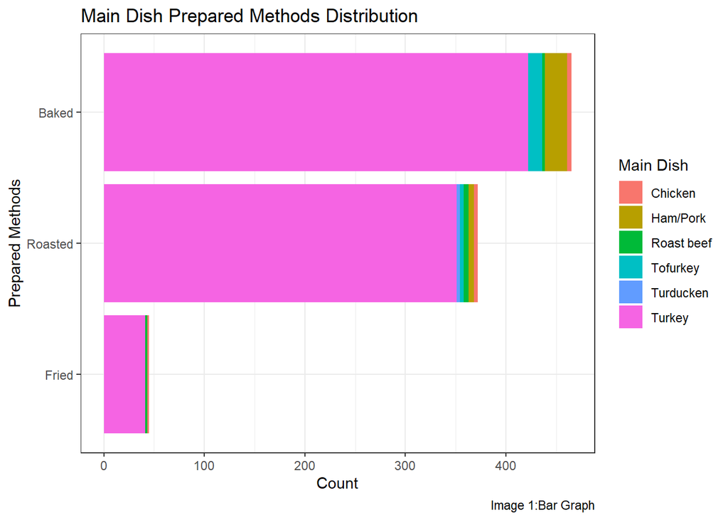

```r
thanksmeals %>%
  filter(!is.na(main_prep),
         !is.na(main_dish),
         !main_dish %in% c("Other (please specify)", "I don't know"),
         !main_prep %in% c("Other (please specify)", "I don't know"))%>%
  count(main_dish, main_prep, sort = TRUE) %>%
  mutate(main_prep = fct_reorder(main_prep, n)) %>%
  ggplot(aes(main_prep, n, fill = main_dish)) +
  geom_col() +
  coord_flip() +
  theme_bw() +
  labs(x="Prepared Methods", y="Count", title="Main Dish Prepared Methods Distribution", fill= "Main Dish", caption = "Image 1:Bar Graph")
```

### 7. How many use cranberry sauce? How many use gravy?

#### In this question, we want to know the quantity so we use `count()` function again. For gravy sauce, there are two types of values, so it is easy to use `filter()` and then count the number to get the result ‘892’. However, for cranberry sauce, there are many types of values, such as other (please specify), homemade, canned and na; therefore, I used filter to deselect na values, but I keep other (please specify) because respondents put the answer in cranberry_other, which belong to the use of cranberry sauce. Then, I count the number and add all count to get the result ‘828’.

```r
# There are 828 people used cranberry sauce.

thanksmeals %>%
  filter(!is.na(cranberry),
         !cranberry=="None") %>%
  count(cranberry) %>%
  select(n) %>%
  summarise(cranberry_sauce = sum(n)) %>%
  kable(caption = "The number of using cranberry sauce")
```

The number of using cranberry sauce

| cranberry_sauce |
| --- |
| 828 |

```r
# There are 892 people used gravy sauce.

thanksmeals %>%
  filter(gravy=="Yes") %>%
  count(gravy) %>%
  kable(caption = "The number of using gravy sauce")
```

The number of using gravy sauce

| gravy | n |
| --- | --- |
| Yes | 892 |

### 8. What is the distribution of those who celebrate across income ranges

#### In this question, I need to count the variables of family_income with people who celebrate. To get the results, I used `group_by()` to group celebrate firstly as well as used `filter()` to filter the variables I want, and finally count the family_income with sorting them in order and `ungroup()` to avoid messing the dataset. In the result, we know there are 166 people celebrate thanksgiving with total income of $25,000 to $49,999 among their family, and followed by $50,000 to $74,999 and $75,000 to $99,999 with both same unmber of 127 people.

```r
thanksmeals %>%
  group_by(celebrate)%>%
  filter(celebrate=="Yes",
         !is.na(family_income),
         !family_income %in% c("Prefer not to answer")) %>%
  count(family_income, sort = TRUE) %>%
  ungroup() %>%
  kable(caption = "Family Income Distribution")
```

Family Income Distribution

| celebrate | family_income | n |
| --- | --- | --- |
| Yes | $25,000 to $49,999 | 166 |
| Yes | $50,000 to $74,999 | 127 |
| Yes | $75,000 to $99,999 | 127 |
| Yes | $100,000 to $124,999 | 109 |
| Yes | $200,000 and up | 76 |
| Yes | $10,000 to $24,999 | 60 |
| Yes | $0 to $9,999 | 52 |
| Yes | $125,000 to $149,999 | 48 |
| Yes | $150,000 to $174,999 | 38 |
| Yes | $175,000 to $199,999 | 26 |

### 9. Present this information in the most evident way on the data viz.

#### I want to create bar chart to show the count for different family income. Most steps at first are the same with Q8. Then, I use `fct_reorder()`to reorder the factor(family_income) level, and I also put `coord_flip()`to avoid the messy of x names. In the graph, we can see the higer family income is $25,000 to $49,999.

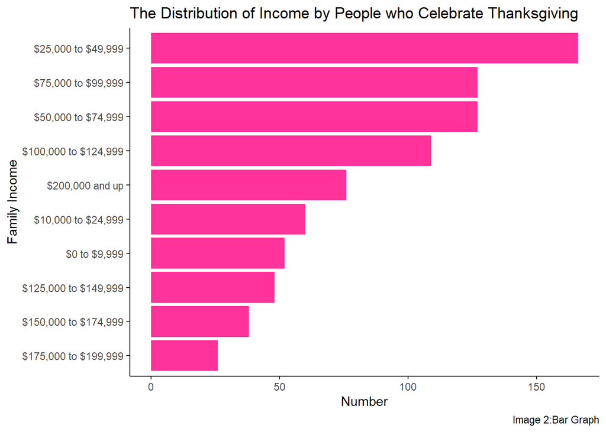

```r
thanksmeals %>%
  filter(celebrate=="Yes",
         !is.na(family_income),
         !family_income %in% c("Prefer not to answer")) %>%
  count(family_income) %>%
  mutate(family_income = fct_reorder(family_income,n)) %>%
  ggplot(aes(family_income,n)) +
  geom_col(fill="#FF3399") +
  coord_flip() +
  theme_classic() +
  labs(x="Family Income", y="Number", title="The Distribution of Income by People who Celebrate Thanksgiving", caption = "Image 2:Bar Graph")
```

### 10. What are the most common pies, sides, and desserts?

#### To count the most repeated values in many columns, we need to use `start_with()` & `gather()` functions. The former is to select the same few words in different columns, while the latter is to gather a set of column name in a type column and their values in another column. Besides, `str_remove()` function is used to delete some characters in a string since I want to make them same type. ( numeric 0-9; : more than one numeric, such as 11,12…) For the result, I use `head()` to only show 10 rows and then use `kable()` to make it clear.

```r
# The most common pie is pumpkin pie.

common_pie <- thanksmeals %>%
  select(starts_with("pie")) %>%
  gather(type,value) %>%
  filter(!is.na(value),
         !value %in% c("None", "Other (please specify)","I don't know")) %>%
  group_by(type) %>%
  count(value, sort = TRUE) %>%
  ungroup() %>%
  mutate(type = str_remove(type, "\\d+"))

head(common_pie,10) %>%
  kable(caption = "Common Pie in Thanksgiving")
```

Common Pie in Thanksgiving

| type | value | n |
| --- | --- | --- |
| pie | Pumpkin | 729 |
| pie | Apple | 514 |
| pie | Pecan | 342 |
| pie | Sweet Potato | 152 |
| pie | Chocolate | 133 |
| pie | Cherry | 113 |
| pie | Key lime | 39 |
| pie | Coconut cream | 36 |
| pie | Buttermilk | 35 |
| pie | Peach | 34 |

```r
# The most common side is mashed potatoes.

common_side <- thanksmeals %>%
  select(starts_with("side")) %>%
  gather(type,value) %>%
  filter(!is.na(value),
         !value %in% c("None", "Other (please specify)","I don't know")) %>%
  group_by(type) %>%
  count(value, sort = TRUE) %>%
  ungroup() %>%
  mutate(type = str_remove(type, "\\d+"))


head(common_side,10) %>%
  kable(caption = "Common Side in Thanksgiving")
```

Common Side in Thanksgiving

| type | value | n |
| --- | --- | --- |
| side | Mashed potatoes | 817 |
| side | Rolls/biscuits | 766 |
| side | Green beans/green bean casserole | 686 |
| side | Yams/sweet potato casserole | 631 |
| side | Corn | 464 |
| side | Carrots | 242 |
| side | Cornbread | 235 |
| side | Fruit salad | 215 |
| side | Vegetable salad | 209 |
| side | Macaroni and cheese | 206 |

```r
# The most common dessert is ice cream.

common_dessert <- thanksmeals %>%
  select(starts_with("dessert")) %>%
  gather(type,value) %>%
  filter(!is.na(value),
         !value %in% c("None", "Other (please specify)","I don't know")) %>%
  group_by(type) %>%
  count(value, sort = TRUE) %>%
  ungroup() %>%
  mutate(type = str_remove(type, "\\d+"))

head(common_dessert,10) %>%
  kable(caption = "Common Dessert in Thanksgiving")
```

Common Dessert in Thanksgiving

| type | value | n |
| --- | --- | --- |
| dessert | Ice cream | 266 |
| dessert | Cookies | 204 |
| dessert | Cheesecake | 191 |
| dessert | Brownies | 128 |
| dessert | Apple cobbler | 110 |
| dessert | Peach cobbler | 103 |
| dessert | Carrot cake | 72 |
| dessert | Fudge | 43 |
| dessert | Blondies | 16 |
| dessert | pie | 13 |

### 11. Present this information on a data viz

#### With `fct_lump()` function, we can limit how many categories we want to show by making other low values into a level called “other”. I believe that bar chart can present well since there is one discrete variable. From the graph, we can know the most common pie is pumpkin pie, the most common side is mashed potatoes, and the most common dessert is ice cream.

#### We can see that the most common pie is pumpkin pie in the graph.

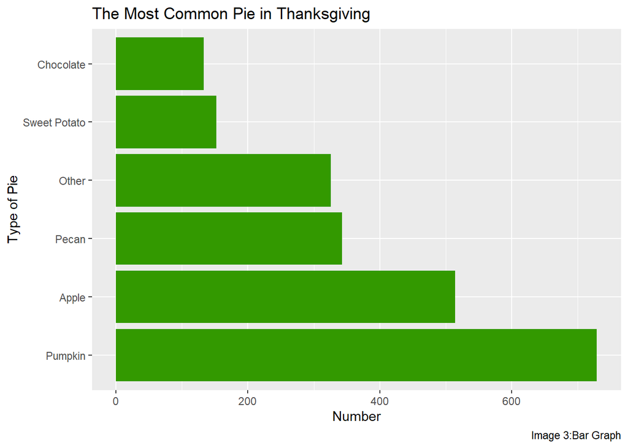

```r
thanksmeals %>%
  select(starts_with("pie")) %>%
  gather(type,value) %>%
  filter(!is.na(value),
         !value %in% c("None", "Other (please specify)","I don't know")) %>%
  mutate(value = fct_lump(value, 5)) %>%
  ggplot(aes(fct_infreq (value)))+
  geom_bar(fill="#339900")+
  coord_flip()+
  theme_gray()+
  labs(x="Type of Pie", y="Number", title="The Most Common Pie in Thanksgiving", caption = "Image 3:Bar Graph")
```

#### Other low values combines into other, so it shows highest; however, the most common side is mashed potatoes.

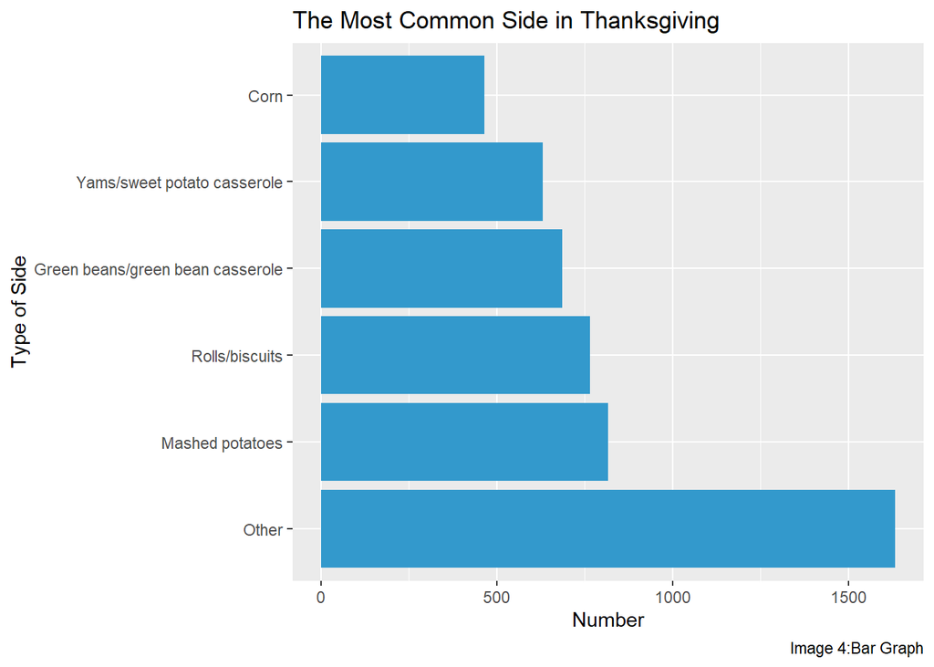

```r
thanksmeals %>%
  select(starts_with("side")) %>%
  gather(type,value) %>%
  filter(!is.na(value),
         !value %in% c("None", "Other (please specify)","I don't know")) %>%
  mutate(value = fct_lump(value, 5)) %>%
  ggplot(aes(fct_infreq (value)))+
  geom_bar(fill="#3399CC")+
  coord_flip()+
  theme_gray()+
  labs(x="Type of Side", y="Number", title="The Most Common Side in Thanksgiving", caption = "Image 4:Bar Graph")
```

#### Other low values combines into other, so it shows highest; however, the most common dessert is ice cream.

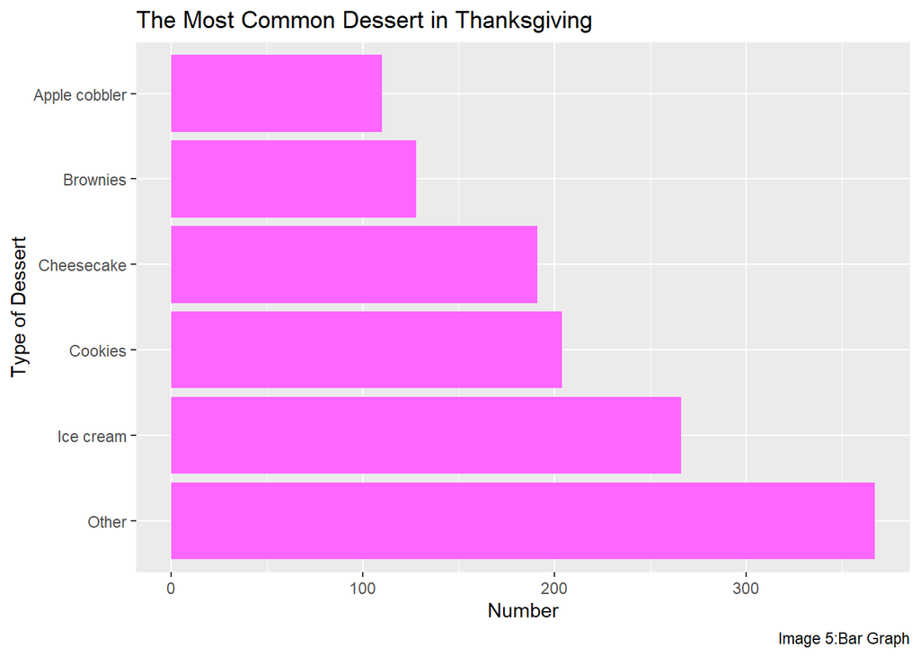

```r
thanksmeals %>%
  select(starts_with("dessert")) %>%
  gather(type,value) %>%
  filter(!is.na(value),
         !value %in% c("None", "Other (please specify)","I don't know")) %>%
  mutate(value = fct_lump(value, 5)) %>%
  ggplot(aes(fct_infreq (value)))+
  geom_bar(fill="#FF66FF")+
  coord_flip()+
  theme_gray()+
  labs(x="Type of Dessert", y="Number", title="The Most Common Dessert in Thanksgiving",caption = "Image 5:Bar Graph")
```

### 12. How do the servings differ by income?

#### In order to compare between family_income and main_dish, I count the family income for each main dish by using `count()` as well as similar functions such as filter and group by, trying to deselect missing values. From the result, we can notice that turkey is the most main dish for most range of family income.

```r
servings_income <- thanksmeals %>%
  select(main_dish,family_income) %>%
  filter(!is.na(main_dish),
         !is.na(family_income),
         !main_dish %in% c("Other (please specify)", "I don't know"),
         !family_income %in% c("None", "Prefer not to answer")) %>%
  group_by(main_dish) %>%
  count(main_dish, family_income, sort = TRUE) %>%
  ungroup()

head(servings_income,11) %>%
  kable(caption = "Comparison between family_income and main_dish")
```

Comparison between family_income and main_dish

| main_dish | family_income | n |
| --- | --- | --- |
| Turkey | $25,000 to $49,999 | 144 |
| Turkey | $50,000 to $74,999 | 118 |
| Turkey | $75,000 to $99,999 | 112 |
| Turkey | $100,000 to $124,999 | 99 |
| Turkey | $200,000 and up | 68 |
| Turkey | $10,000 to $24,999 | 47 |
| Turkey | $0 to $9,999 | 43 |
| Turkey | $125,000 to $149,999 | 43 |
| Turkey | $150,000 to $174,999 | 34 |
| Turkey | $175,000 to $199,999 | 23 |
| Ham/Pork | $75,000 to $99,999 | 8 |

### 13. Present this information on a data viz

#### I present the result with three types of data viz for this question. To show the distribution for each main dish and family income, I use bar chart to present fot the first graph. I use fuctions to reorder factor level. After that, flip the x and y position after ggplot the data in order to make the name of x variables clear. In this graph, we can see there is a big gap between turkey and other main dish in the graph. in the second graph I created, we can see most people with family income range from $25,000 to $49,999 celebrate thanksgiving, and turkey is the most popular main dish among all range of family income. In the last graph, I created with different variable. I put main dish and family income in x and y (both are discrete), we can see the distribution with different size of dots representing different number.

#### There is a huge gap between turkey and other main dish with all range of family income.

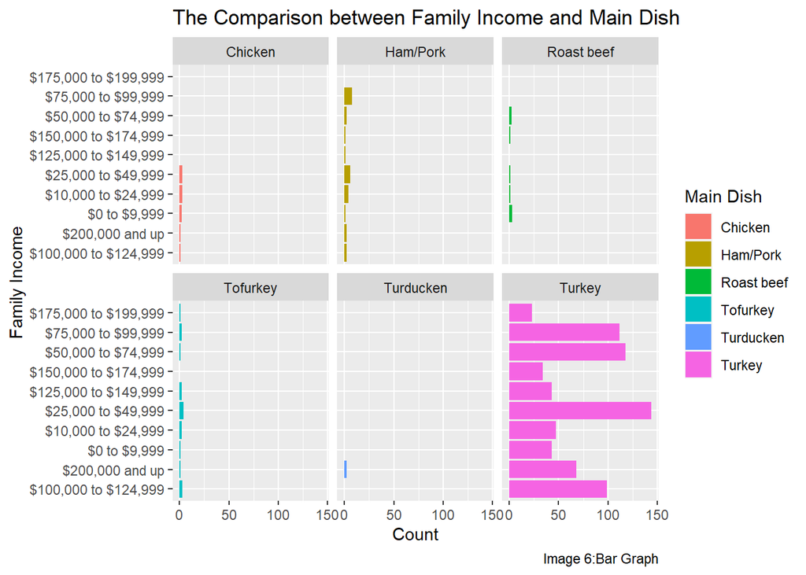

```r
servings_income %>%
  group_by(main_dish) %>%
  mutate(family_income = fct_reorder(family_income, n)) %>%
  ungroup() %>%
  ggplot(aes(family_income,n, fill=main_dish))+
  geom_col()+
  coord_flip()+
  facet_wrap(~main_dish)+
  labs(x="Family Income", y="Count", title="The Comparison between Family Income and Main Dish", fill="Main Dish", caption = "Image 6:Bar Graph")
```

#### We can see most people with family income range from $25,000 to $49,999 celebrate thanksgiving, and turkey is the most popular main dish among all range of family income.

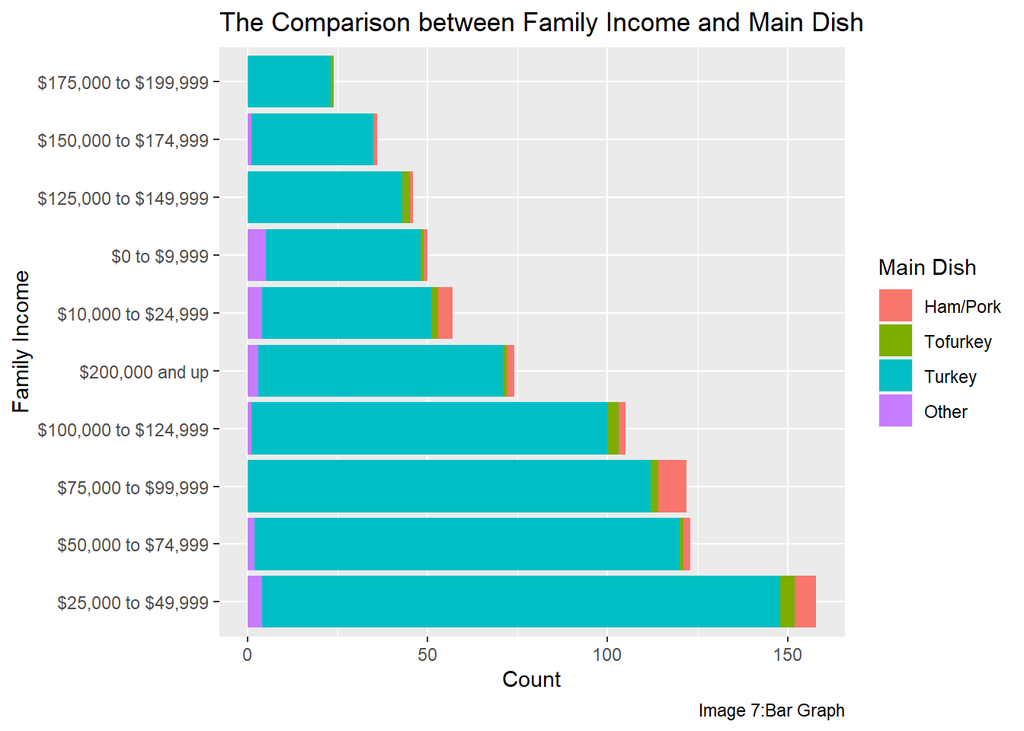

```r
thanksmeals %>%
  select(main_dish,family_income) %>%
  filter(!is.na(main_dish),
         !is.na(family_income),
         !main_dish %in% c("Other (please specify)", "I don't know"),
         !family_income %in% c("None", "Prefer not to answer")) %>%
  mutate(main_dish = fct_lump(main_dish, 3)) %>%
  ggplot(aes(fct_infreq(family_income), fill=main_dish))+
  geom_bar()+
  coord_flip()+
  labs(x="Family Income", y="Count", title="The Comparison between Family Income and Main Dish", fill="Main Dish", caption = "Image 7:Bar Graph")
```

#### If I put main dish and family income in x and y (both are discrete), we can see the distribution with different size of dots representing different number.

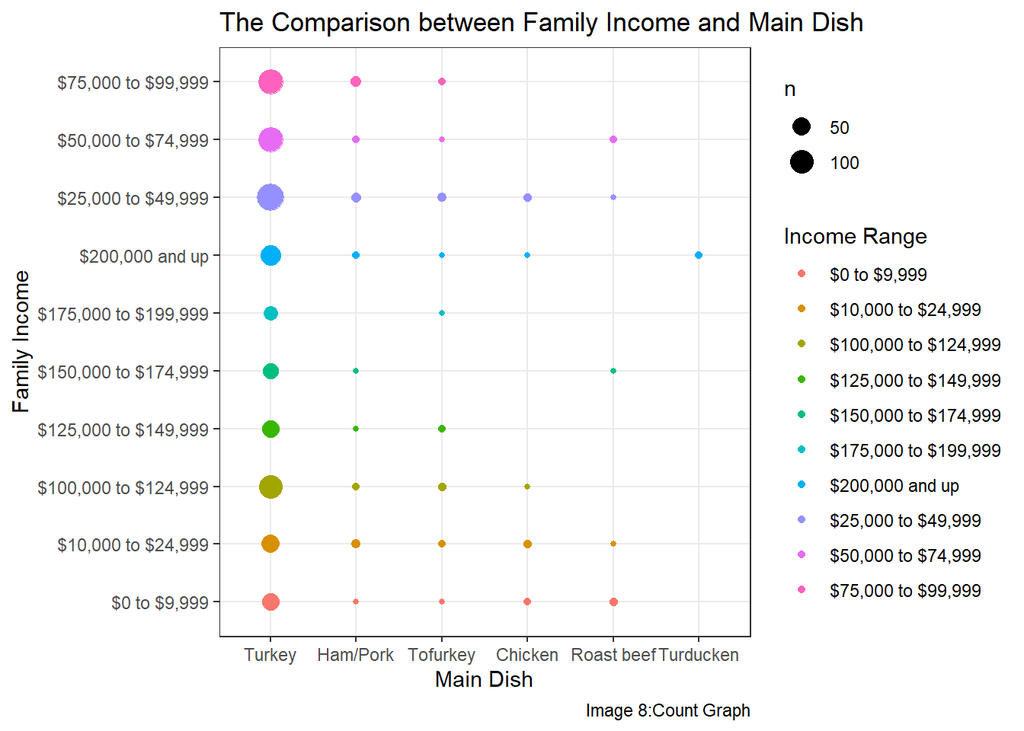

```r
thanksmeals %>%
  select(main_dish,family_income) %>%
  filter(!is.na(main_dish),
         !is.na(family_income),
         !main_dish %in% c("Other (please specify)", "I don't know"),
         !family_income %in% c("None", "Prefer not to answer")) %>%
  mutate(main_dish = fct_lump( main_dish, n=5)) %>%
  ggplot(aes(fct_infreq(main_dish), family_income, color=family_income))+
  geom_count()+
  theme_bw()+
  labs(x="Main Dish", y="Family Income", title="The Comparison between Family Income and Main Dish", color = "Income Range", caption = "Image 8:Count Graph")
```